# Evaluation of basketball statistics

Blake Nelson, Nick Olech

2024-03-28

# Description of Data Set

For our project we are combining two different data sets. The first data frame has information for each player such as personal information and draft information like what position, draft year, and draft team. The second dataframe gives year by year information for each player in the first data frame. This information includes salary, season, and team.

### Loading packages and data frames

```r
library(ggplot2)
library(tidyverse)
library(dplyr)
library(scales)
```

```r
#Draft information Data Frame
df1 <-
  read.csv(
    "https://query.data.world/s/7fyub35dc6n4crgjosveptbc7uxeo3?dws=00000",
    header = TRUE,
    stringsAsFactors = FALSE
  )

#Salary information Data Frame
df2 <-
  read.csv(
    "https://query.data.world/s/6xhwdm7emdeglx4botceotj6udfevo?dws=00000",
    header = TRUE,
    stringsAsFactors = FALSE
  )
```

# First Data Cleaning Steps

```r
#Merge df1 (draft info) and df2 (salary statistics)
nba_stats <-
  merge(df2,
        df1,
        by.x = "player_id",
        by.y = "X_id",
        all.x = TRUE)
```

```r
#Drop player that were drafted before 1980
nba_stats <- nba_stats %>%
  filter(draft_year >= 1980)

#Replaces empty values with NA
nba_stats <- nba_stats %>%
  mutate(across(where(is.character), ~na_if(.x, "")))
```

Note: Players that were drafted before 1980 are not accounted for in order to be more indicative of the modern era.

# Marginal Summaries

```r
head(nba_stats)
```

```
##   player_id league  salary  season season_end season_start
## 1 abdelal01    NBA  395000 1990-91       1991         1990
## 2 abdelal01    NBA  494000 1991-92       1992         1991
## 3 abdelal01    NBA  500000 1992-93       1993         1992
## 4 abdelal01    NBA  805000 1993-94       1994         1993
## 5 abdelal01    NBA  650000 1994-95       1995         1994
## 6 abdulma02    NBA 1660000 1990-91       1991         1990
##                     team     birthDate            birthPlace career_AST
## 1 Portland Trail Blazers June 24, 1968          Cairo, Egypt        0.3
## 2 Portland Trail Blazers June 24, 1968          Cairo, Egypt        0.3
## 3         Boston Celtics June 24, 1968          Cairo, Egypt        0.3
## 4         Boston Celtics June 24, 1968          Cairo, Egypt        0.3
## 5       Sacramento Kings June 24, 1968          Cairo, Egypt        0.3
## 6         Denver Nuggets March 9, 1969 Gulfport, Mississippi        3.5
##   career_FG. career_FG3. career_FT. career_G career_PER career_PTS career_TRB
```

[output cut: 27 more lines]

```r
summary(nba_stats)
```

```
##   player_id            league              salary            season
##  Length:11845       Length:11845       Min.   :    2706   Length:11845
##  Class :character   Class :character   1st Qu.:  790440   Class :character
##  Mode  :character   Mode  :character   Median : 1774000   Mode  :character
##                                        Mean   : 3527175
##                                        3rd Qu.: 4420000
##                                        Max.   :34682550
##    season_end    season_start      team            birthDate
##  Min.   :1985   Min.   :1984   Length:11845       Length:11845
##  1st Qu.:1997   1st Qu.:1996   Class :character   Class :character
##  Median :2004   Median :2003   Mode  :character   Mode  :character
##  Mean   :2004   Mean   :2003
##  3rd Qu.:2012   3rd Qu.:2011
##  Max.   :2018   Max.   :2017
##   birthPlace          career_AST      career_FG.        career_FG3.
##  Length:11845       Min.   : 0.000   Length:11845       Length:11845
##  Class :character   1st Qu.: 0.800   Class :character   Class :character
##  Mode  :character   Median : 1.600   Mode  :character   Mode  :character
##                     Mean   : 2.092
##                     3rd Qu.: 2.900
##                     Max.   :10.500
##   career_FT.           career_G       career_PER          career_PTS
##  Length:11845       Min.   :   1.0   Length:11845       Min.   : 0.000
##  Class :character   1st Qu.: 361.0   Class :character   1st Qu.: 5.700
##  Mode  :character   Median : 630.0   Mode  :character   Median : 8.700
##                     Mean   : 627.3                      Mean   : 9.604
##                     3rd Qu.: 867.0                      3rd Qu.:12.800
##                     Max.   :1522.0                      Max.   :30.100
##   career_TRB         career_WS         career_eFG.          college
##  Length:11845       Length:11845       Length:11845       Length:11845
##  Class :character   Class :character   Class :character   Class :character
##  Mode  :character   Mode  :character   Mode  :character   Mode  :character
##
##
##
##   draft_pick        draft_round         draft_team         draft_year
##  Length:11845       Length:11845       Length:11845       Length:11845
##  Class :character   Class :character   Class :character   Class :character
##  Mode  :character   Mode  :character   Mode  :character   Mode  :character
##
##
##
##     height           highSchool            name             position
##  Length:11845       Length:11845       Length:11845       Length:11845
##  Class :character   Class :character   Class :character   Class :character
##  Mode  :character   Mode  :character   Mode  :character   Mode  :character
##
##
##
##     shoots             weight
##  Length:11845       Length:11845
##  Class :character   Class :character
##  Mode  :character   Mode  :character
##
##
##
```

```r
dim(nba_stats)
```

```
## [1] 11845    30
```

First I want to look at the overall salaries that are listed in this dataset to get a sort of gague of what the numbers should look like.

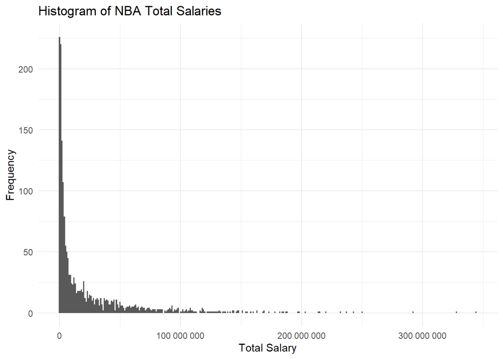

```r
#Make so there are no repeat id's and get salary statistics
nba_salary_summary <- nba_stats %>%
  group_by(player_id) %>%
  summarize(
    Total_Salary = sum(salary, na.rm = TRUE),
    Average_Salary = mean(salary, na.rm = TRUE),
    .groups = 'drop'
  )

#Graph to see how much the average player made over their career
ggplot(data = nba_salary_summary, aes(x = Total_Salary)) +
  geom_histogram(binwidth = 1000000) +
  scale_x_continuous(labels = label_number()) +
  labs(title = "Histogram of NBA Total Salaries",
       x = "Total Salary",
       y = "Frequency") +
  theme_minimal()
```

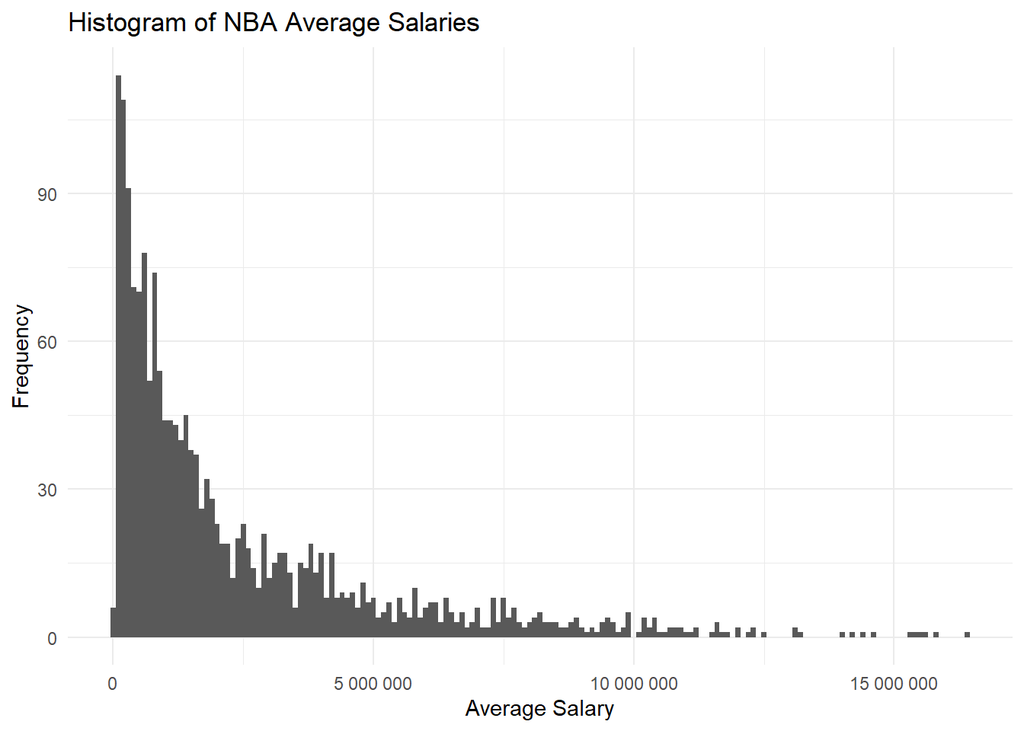

```r
#Graph to see how much the average player makes over the course of one singular season
ggplot(data = nba_salary_summary, aes(x = Average_Salary)) +
  geom_histogram(binwidth = 100000) +
  scale_x_continuous(labels = label_number()) +
  labs(title = "Histogram of NBA Average Salaries",
       x = "Average Salary",
       y = "Frequency") +
  theme_minimal()
```

I am a little concerned that this dataset is not representative of how much players have made but since the data is pre 2019 this makes sense.

NBA salaries are increasingly inflated, especially in the last half decade, therefore it makes sense these numbers are lower than we are nowadays accustomed to.

```r
library(dplyr)

# Checking for average salaries greater than $15 million
high_salary_players <- nba_salary_summary %>%
  filter(Average_Salary > 15000000)

# Viewing the results
print(high_salary_players)
```

```
## # A tibble: 6 × 3
##   player_id Total_Salary Average_Salary
##   <chr>            <int>          <dbl>
## 1 anthoca01    232001415      15466761
## 2 bryanko01    328238062      16411903.
## 3 garneke01    343872398      15630564.
## 4 howardw01    213765862      15268990.
## 5 jamesle01    237020472      15801365.
## 6 onealsh01    292198327      15378859.
```

```r
count(high_salary_players)
```

```
## # A tibble: 1 × 1
##       n
##   <int>
## 1     6
```

Now lets look to answer “Does where you are born influence your likely hood of NBA success?”

```r
#Separate the birthplace column into two separate rows and look at what city/state they are from
nba_birthplace_summary <- nba_stats %>%
  distinct(player_id, .keep_all = TRUE) %>%
  separate(birthPlace, into = c("City", "State_Country"), sep = ", ", extra = "merge") %>%
  group_by(player_id, State_Country) %>%
  ungroup() %>%
  count(State_Country, sort = TRUE)
#Same thing now, except group by city
nba_birthplacecity_summary <- nba_stats %>%
  distinct(player_id, .keep_all = TRUE) %>%
  separate(birthPlace, into = c("City", "State_Country"), sep = ", ", extra = "merge") %>%
  group_by(player_id, City) %>%
  ungroup() %>%
  count(City, sort = TRUE)
```

# Questions to possibly research

What is the ideal height/weight (build) of an NBA Player? - Could look at how salary relates to certain measurements a player has.

```r
str(nba_stats)
```

```
## 'data.frame':    11845 obs. of  30 variables:
##  $ player_id   : chr  "abdelal01" "abdelal01" "abdelal01" "abdelal01" ...
##  $ league      : chr  "NBA" "NBA" "NBA" "NBA" ...
##  $ salary      : int  395000 494000 500000 805000 650000 1660000 2008000 2358000 1825000 2200000 ...
##  $ season      : chr  "1990-91" "1991-92" "1992-93" "1993-94" ...
##  $ season_end  : int  1991 1992 1993 1994 1995 1991 1992 1993 1994 1995 ...
##  $ season_start: int  1990 1991 1992 1993 1994 1990 1991 1992 1993 1994 ...
##  $ team        : chr  "Portland Trail Blazers" "Portland Trail Blazers" "Boston Celtics" "Boston Celtics" ...
##  $ birthDate   : chr  "June 24, 1968" "June 24, 1968" "June 24, 1968" "June 24, 1968" ...
##  $ birthPlace  : chr  "Cairo, Egypt" "Cairo, Egypt" "Cairo, Egypt" "Cairo, Egypt" ...
##  $ career_AST  : num  0.3 0.3 0.3 0.3 0.3 3.5 3.5 3.5 3.5 3.5 ...
##  $ career_FG.  : chr  "50.2" "50.2" "50.2" "50.2" ...
##  $ career_FG3. : chr  "0.0" "0.0" "0.0" "0.0" ...
##  $ career_FT.  : chr  "70.1" "70.1" "70.1" "70.1" ...
##  $ career_G    : int  256 256 256 256 256 586 586 586 586 586 ...
```

[output cut: 16 more lines]

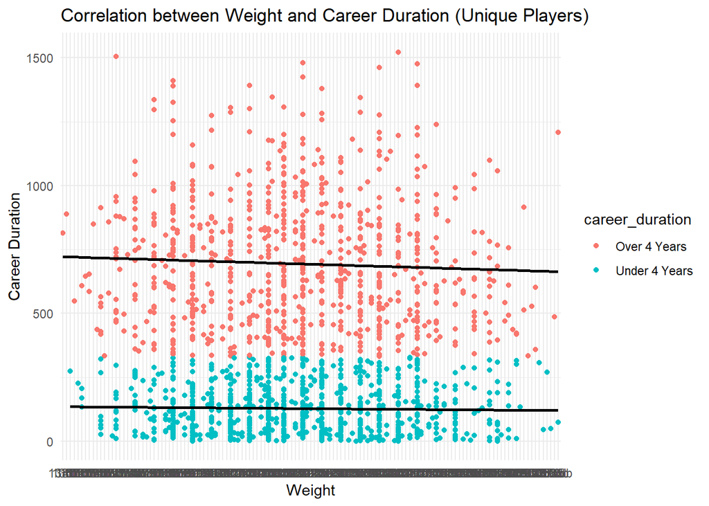

```r
# Create a copy of nba_stats
ns_w_cd <- nba_stats

# Add career_duration column
ns_w_cd$career_duration <- ifelse(ns_w_cd$career_G > 4*82, "Over 4 Years", "Under 4 Years")

# Filter to include only unique player IDs
unique_players <- ns_w_cd %>%
  distinct(player_id, .keep_all = TRUE)

# Plotting the correlation between weight and career duration
weight_duration_plot <- ggplot(unique_players, aes(x = weight, y = career_G, color = career_duration)) +
  geom_point() +
  geom_smooth(aes(group = career_duration), method = "lm", se = FALSE, color = "black") +  # Add black linear regression lines
  labs(title = "Correlation between Weight and Career Duration (Unique Players)", x = "Weight", y = "Career Duration") +
  theme_minimal()

# Display the plot
print(weight_duration_plot)
```

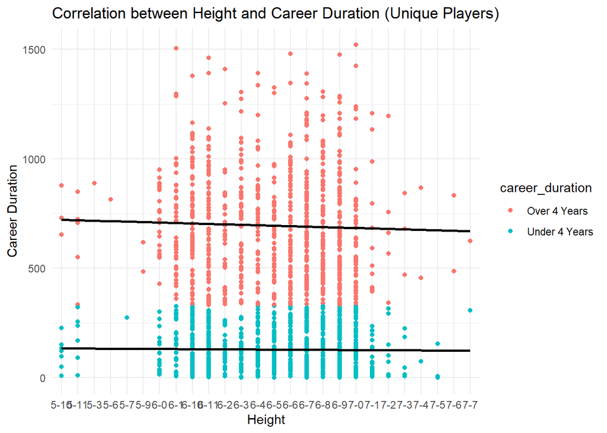

```r
# Plotting the correlation between height and career duration
height_duration_plot <- ggplot(unique_players, aes(x = height, y = career_G, color = career_duration)) +
  geom_point() +
  geom_smooth(aes(group = career_duration), method = "lm", se = FALSE, color = "black") +  # Add black linear regression lines
  labs(title = "Correlation between Height and Career Duration (Unique Players)", x = "Height", y = "Career Duration") +
  theme_minimal()

# Display the plot
print(height_duration_plot)
```

```r
# Convert height from feet-inches format to inches
height_inches <- sapply(strsplit(unique_players$height, "-"), function(x) as.numeric(x[1]) * 12 + as.numeric(x[2]))

# Calculate average height (in inches) and weight (in pounds)
average_height_inches <- mean(height_inches, na.rm = TRUE)
average_weight <- mean(as.numeric(gsub("lb", "", unique_players$weight)), na.rm = TRUE)

# Convert average height from inches to feet-inches format
average_height_feet <- floor(average_height_inches / 12)
average_height_remainder <- round(average_height_inches %% 12)
average_height <- paste(average_height_feet, "ft", average_height_remainder, "in")

# Print the results
cat("Average Height:", average_height, "\n")
```

```
## Average Height: 6 ft 7 in
```

```r
cat("Average Weight:", round(average_weight, 2), "lb\n")
```

```
## Average Weight: 218.62 lb
```

Does where you are born influence your likely hood of NBA success? - Could look at salary or sheer number of NBA players from certain regions and then divide by each respective population.

What position in basketball seems to contribute to winning the most?

- Could look to analyze win shares and other statistics relating to positions.

Ideas Look to model the perfect NBA “prospect” Utilize comparative analysis in order to predict future player success.